# 18 Confianza en los niveles de Gobierno

Autor/a

Lic. María Fernanda Rojas Barrera

Fecha de publicación

16 de octubre de 2025

## 18.1 AVISO GENERAL

A partir de este capítulo, comienzan las Secciones IV que se preguntan en diferentes periodos del año, para el caso de la **Confianza en los niveles de Gobierno**, es una sola pregunta que se comenzó a realizar en cada trimestre impar desde 2023 y que ha tenido dos cambios en la forma de realizarse.

- Pregunta original (1er trimestre 2023 a 1er trimestre de 2024)

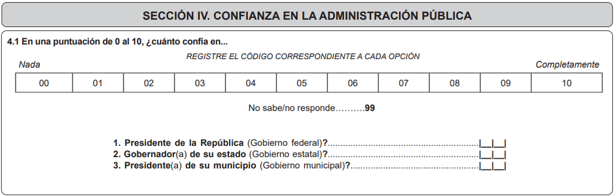

Fuente: [Encuesta Nacional de Seguridad Pública Urbana (2023). Encuesta Nacional de Seguridad Pública Urbana 2023 : ENSU : informe operativo : información complementaria al 1° trimestre / Instituto Nacional de Estadística y Geografía.– México : INEGI, c2023.]

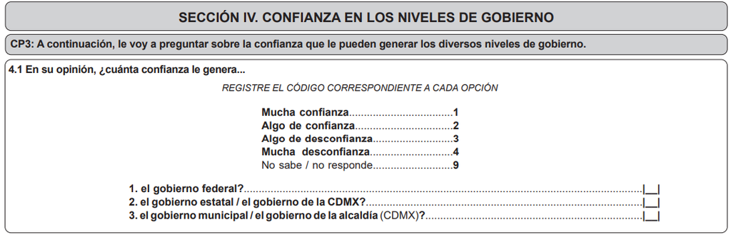

Fuente: [Encuesta Nacional de Seguridad Pública Urbana (2025). Encuesta Nacional de Seguridad Pública Urbana 2025 : ENSU : informe operativo : información complementaria al 1° trimestre / Instituto Nacional de Estadística y Geografía.– México : INEGI, c2025.]

Dependiendo de si el periodo a evaluar es igual o antes de 1t24 tiene 12 opciones posibles de respuesta (00 a 10 y 99) y si es igual o después de 3t24 tiene 5 opciones posibles de respuesta (1 a 4 y 9).

Para poder realizar un análisis histórico de la información disponible, se procedió a realizar una homologación de las categorías antiguas con las actuales, es decir, reestructurar a las 5 categorías actuales y además crear la sexta y séptima categoría, siendo estas: “Mucha o algo de confianza” y “Algo o mucha desconfianza”, para replicar los resultados que otorga el INEGI en sus tabulados. La homologación de las categorías antiguas se realiza conforme al reporte del INEGI del 1er trimestre de 2023 (página 76).

[figure not shown]

Los resultados de este apartado pueden ser corroborados en los tabulados complementarios de la ENSU, especificamente en los archivos con la siguiente nomenclatura: `14.Com_confianza_niveles_gob_MES_ANIO_est`. No obstante, se hace mención que esta pregunta comenzó a hacerse en la ENSU a partir del 1er trimestre de 2023.

### 18.2.1 General

[interactive chart not shown]

### 18.2.2 Hombres

[interactive chart not shown]

### 18.2.3 Mujeres

[interactive chart not shown]

### 18.3.1 General

[interactive chart not shown]

Para realizar una comparación entre ciudades se puede recurrir al uso del siguiente gráfico, seleccionando la ciudad de interés.

**Mostrar gráfica 2 - General**

[interactive chart not shown]

### 18.3.2 Hombres

[interactive chart not shown]

Para realizar una comparación entre ciudades se puede recurrir al uso del siguiente gráfico, seleccionando la ciudad de interés.

**Mostrar gráfica 2 - Hombres**

[interactive chart not shown]

### 18.3.3 Mujeres

[interactive chart not shown]

Para realizar una comparación entre ciudades se puede recurrir al uso del siguiente gráfico, seleccionando la ciudad de interés.

**Mostrar gráfica 2 - Mujeres**

[interactive chart not shown]

### 18.4.1 General

[interactive chart not shown]

### 18.4.2 Hombres

[interactive chart not shown]

### 18.4.3 Mujeres

[interactive chart not shown]